# Grids in two space dimensions

[AMath 585, Winter Quarter 2020](http://staff.washington.edu/rjl/classes/am585w2020/) at the University of Washington. Developed by R.J. LeVeque and distributed under the [BSD license](https://github.com/rjleveque/amath585w2020/blob/master/LICENSE). You are free to modify and use as you please, with attribution.

These notebooks are all [available on Github](https://github.com/rjleveque/amath585w2020/).

This notebook illustrates how to define a function $u(x,y)$ on a two-dimensional grid, with some demos of different ways to plot such functions.

```python
%matplotlib inline
```

```python
from pylab import *
from scipy import sparse
```

## Defining 2D grid functions

In two space dimensions we will be approximating functions of $(x,y)$ by arrays with two indices so that $U_{ij} \approx u(x_i, y_j)$. So it is natural to define a 2D numpy array `U` so that `U[i,j] =` $U_{ij}$.

```python
mx = 9
x = linspace(0,1,mx+2)
print('x = ',x)

my = 3
y = linspace(5,6,my+2)
print('y = ',y)

# turn into 2D arrays:
X,Y = meshgrid(x,y,indexing='ij')

print('X = \n', X)
print('Y = \n', Y)
print()
```

```
x =  [0.  0.1 0.2 0.3 0.4 0.5 0.6 0.7 0.8 0.9 1. ]
y =  [5.   5.25 5.5  5.75 6.  ]
X =
 [[0.  0.  0.  0.  0. ]
 [0.1 0.1 0.1 0.1 0.1]
 [0.2 0.2 0.2 0.2 0.2]
 [0.3 0.3 0.3 0.3 0.3]
 [0.4 0.4 0.4 0.4 0.4]
 [0.5 0.5 0.5 0.5 0.5]
 [0.6 0.6 0.6 0.6 0.6]
 [0.7 0.7 0.7 0.7 0.7]
 [0.8 0.8 0.8 0.8 0.8]
 [0.9 0.9 0.9 0.9 0.9]
 [1.  1.  1.  1.  1. ]]
Y =
 [[5.   5.25 5.5  5.75 6.  ]
 [5.   5.25 5.5  5.75 6.  ]
 [5.   5.25 5.5  5.75 6.  ]
 [5.   5.25 5.5  5.75 6.  ]
 [5.   5.25 5.5  5.75 6.  ]
 [5.   5.25 5.5  5.75 6.  ]
 [5.   5.25 5.5  5.75 6.  ]
 [5.   5.25 5.5  5.75 6.  ]
 [5.   5.25 5.5  5.75 6.  ]
 [5.   5.25 5.5  5.75 6.  ]
 [5.   5.25 5.5  5.75 6.  ]]
```

Note that the arrays `X,Y` are defined so that `(X[i,j], Y[i,j]) = (x[i], y[j])` is the `(i,j)` grid point:

```python
i = 2
j = 1
print('x[i] = ',x[i], '  y[j] = ', y[j])
print('X[i,j] = ',X[i,j], '  Y[i,j] = ',Y[i,j])
```

```
x[i] =  0.2   y[j] =  5.25
X[i,j] =  0.2   Y[i,j] =  5.25
```

Having 2D arrays `X,Y` makes it easier to evaluate a function at all the grid points, e.g.

```python
U = X + 10*Y
print('U = \n', U)
```

```
U =
 [[50.  52.5 55.  57.5 60. ]
 [50.1 52.6 55.1 57.6 60.1]
 [50.2 52.7 55.2 57.7 60.2]
 [50.3 52.8 55.3 57.8 60.3]
 [50.4 52.9 55.4 57.9 60.4]
 [50.5 53.  55.5 58.  60.5]
 [50.6 53.1 55.6 58.1 60.6]
 [50.7 53.2 55.7 58.2 60.7]
 [50.8 53.3 55.8 58.3 60.8]
 [50.9 53.4 55.9 58.4 60.9]
 [51.  53.5 56.  58.5 61. ]]
```

```python
i=5
j=3
print('x[i] = ',x[i], '  y[j] = ', y[j])
print('U[i,j] = ', U[i,j])
```

```
x[i] =  0.5   y[j] =  5.75
U[i,j] =  58.0
```

## Plotting the grid lines / points

We can use the fact that `plot(X,Y)` plots each column of `X` against the corresponding column of `Y` to produce one set of grid lines, and then transpose the matrices to plot the others, e.g.

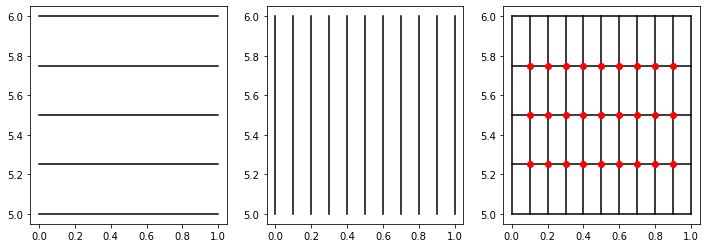

```python
figure(figsize=(12,4))

subplot(1,3,1)
plot(X,Y,'k')

subplot(1,3,2)
plot(X.T,Y.T,'k')

subplot(1,3,3)
plot(X,Y,'k')
plot(X.T,Y.T,'k')

# put red dots at the interior points:
plot(X[1:-1,1:-1],Y[1:-1,1:-1],'ro');
```

Make a little function to plot grids this way:

We also use `axis('scaled')` so that squares turn out square (one unit in `x` is the same length as in `y`).

```python
def plot_grid(X,Y):
    plot(X,Y,'k')
    plot(X.T,Y.T,'k')
    #plot(X[1:-1,1:-1],Y[1:-1,1:-1],'ro') # for the red dots
    axis('scaled')
```

## Contour plots

The [matplotlib contour](https://matplotlib.org/api/_as_gen/matplotlib.pyplot.contour.html) command can be used to make contour plots:

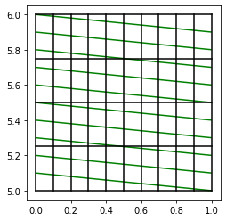

```python
plot_grid(X,Y)
contour(X,Y,U,range(50,62,1),colors='g');
```

### Filled contours

The [contourf](https://matplotlib.org/api/_as_gen/matplotlib.pyplot.contourf.html) command can be used to plot filled contours. Here we use the default colormap:

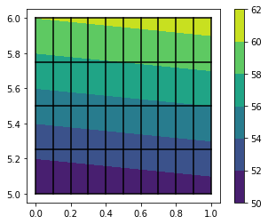

```python
plot_grid(X,Y)
contourf(X,Y,U,range(50,63,2))
colorbar()
```

Many other colormaps are available or you can generate your own. See in particular:

- [Choosing colormaps in matplotlib](https://matplotlib.org/3.1.0/tutorials/colors/colormaps.html)
- [Creating colormaps in matplotlib](https://matplotlib.org/3.1.0/tutorials/colors/colormap-manipulation.html)

```python
cmap_cool=get_cmap('cool')  # uses function from matplotlib.pyplot
```

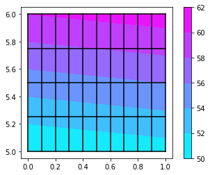

```python
plot_grid(X,Y)
contourf(X,Y,U,range(50,63,2), cmap=cmap_cool)
colorbar();
```

### Choice of colormaps

For many years "jet" was the default colormap in Matlab and also Matplotlib, but this is known to be a poor choice for many reasons. Depending on what you are trying to show, the choice of a good colormap can be critical. See for example,

- [How bad is your colormap?](https://jakevdp.github.io/blog/2014/10/16/how-bad-is-your-colormap/)
- [A dangerous rainbow: Why colormaps matter](https://blogs.mathworks.com/headlines/2018/10/10/a-dangerous-rainbow-why-colormaps-matter/)

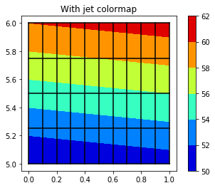

```python
plot_grid(X,Y)
contourf(X,Y,U,range(50,63,2), cmap=get_cmap('jet'))
colorbar();
title('With jet colormap');
```

## pcolor plots

The [pcolor](https://matplotlib.org/api/_as_gen/matplotlib.pyplot.pcolor.html) and [pcolormesh](https://matplotlib.org/api/_as_gen/matplotlib.pyplot.pcolormesh.html) functions are similar but the latter is more efficient if the grid is uniform. By default it gives uniform colors or patches defined by `X,Y`, but perhaps not what you expect to see. Although `X, Y, U` are all $11\times 5$ arrays, `pcolor` gives a $10\times 4$ array of patches, colored according to the value of `U` at the bottom left corner of a patch (see the documentation).

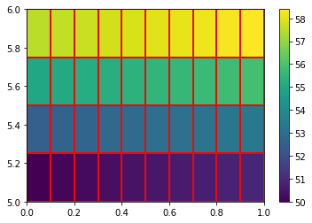

```python
pcolormesh(X,Y,U,edgecolors='r')
colorbar();
```

With more work you can get `pcolormesh` to plot patches that are centered at the `X,Y` points. In particular, `X,Y` have to be one row and column larger than `U` in order to use all the data in `U`.

```
Xcells.shape =  (12, 6)
U.shape =  (11, 5)
```

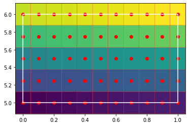

```python
dx = x[1] - x[0]
dy = y[1] - y[0]
mx = len(x) - 2
my = len(y) - 2
xcells = linspace(x[0]-dx/2, x[-1]+dx/2, mx+3)
ycells = linspace(y[0]-dy/2, y[-1]+dy/2, my+3)
Xcells,Ycells = meshgrid(xcells,ycells,indexing='ij')
pcolor(Xcells,Ycells,U,edgecolors='r')
plot(X,Y,'ro')
#axis('scaled')

# plot a white box around the actual domain,
# assuming `X,Y` points lie on boundary:
plot([x[0],x[-1],x[-1],x[0],x[0]],  [y[0],y[0],y[-1],y[-1],y[0]], 'w');

# restrict plot to interior points if desired:
#xlim(x[0],x[-1])
#ylim(y[0],y[-1])

print('Xcells.shape = ', Xcells.shape)
print('U.shape = ', U.shape)
```

For our plotting purposes it's easiest to use `contourf`.